# BA- Final Project

Akshaya Mamidipalli

2023-12-10

17. Zillow’s Zestimate home valuation has shaken up the U.S. real estate industry since first released 11 years ago. A home is often the largest and most expensive purchase a person makes in his or her lifetime. Ensuring homeowners have a trusted way to monitor this asset is incredibly important. The Zestimate was created to give consumers as much information as possible about homes and the housing market, marking the first-time consumers had access to this type of home value information at no cost. “Zestimates” are estimated home values based on 7.5 million statistical and machine learning models that analyze hundreds of data points on each property. And, by continually improving the median margin of error (from 14% at the onset to 5% today), Zillow has since become established as one of the largest, most trusted marketplaces for real estate information in the U.S. and a leading example of impactful machine learning. This project is the very simplified version of Zillow Prize competition. Zillow Prize was a competition with a one-million-dollar grand prize with the objective to help push the accuracy of the Zestimate even further. Winning algorithms stand to impact the home values of 110M homes across the U.S.

#Instaling the required libraries.

```r
library(ggplot2)
library(caret)
library(rpart)
```

#Loading the “House prices.csv” as training data set.

```r
training_data <- read.csv("C:/Users/navat/Downloads/House_Prices (1).csv")
```

```r
head(training_data)
```

```
##   LotArea OverallQual YearBuilt YearRemodAdd BsmtFinSF1 FullBath HalfBath
## 1    8450           7      2003         2003        706        2        1
## 2    9600           6      1976         1976        978        2        0
## 3   11250           7      2001         2002        486        2        1
## 4    9550           7      1915         1970        216        1        0
## 5   14260           8      2000         2000        655        2        1
## 6   14115           5      1993         1995        732        1        1
##   BedroomAbvGr TotRmsAbvGrd Fireplaces GarageArea YrSold SalePrice
## 1            3            8          0        548   2008    208500
## 2            3            6          1        460   2007    181500
## 3            3            6          1        608   2008    223500
## 4            3            7          1        642   2006    140000
## 5            4            9          1        836   2008    250000
## 6            1            5          0        480   2009    143000
```

```r
summary(training_data)
```

```
##     LotArea        OverallQual       YearBuilt     YearRemodAdd
##  Min.   :  1491   Min.   : 1.000   Min.   :1880   Min.   :1950
##  1st Qu.:  7585   1st Qu.: 5.000   1st Qu.:1954   1st Qu.:1968
##  Median :  9442   Median : 6.000   Median :1973   Median :1994
##  Mean   : 10795   Mean   : 6.136   Mean   :1971   Mean   :1985
##  3rd Qu.: 11618   3rd Qu.: 7.000   3rd Qu.:2000   3rd Qu.:2004
##  Max.   :215245   Max.   :10.000   Max.   :2010   Max.   :2010
##    BsmtFinSF1        FullBath        HalfBath       BedroomAbvGr
##  Min.   :   0.0   Min.   :0.000   Min.   :0.0000   Min.   :0.000
##  1st Qu.:   0.0   1st Qu.:1.000   1st Qu.:0.0000   1st Qu.:2.000
##  Median : 384.0   Median :2.000   Median :0.0000   Median :3.000
##  Mean   : 446.5   Mean   :1.564   Mean   :0.3856   Mean   :2.843
##  3rd Qu.: 728.8   3rd Qu.:2.000   3rd Qu.:1.0000   3rd Qu.:3.000
##  Max.   :2260.0   Max.   :3.000   Max.   :2.0000   Max.   :8.000
##   TotRmsAbvGrd      Fireplaces       GarageArea         YrSold
##  Min.   : 2.000   Min.   :0.0000   Min.   :   0.0   Min.   :2006
##  1st Qu.: 5.000   1st Qu.:0.0000   1st Qu.: 336.0   1st Qu.:2007
##  Median : 6.000   Median :1.0000   Median : 480.0   Median :2008
##  Mean   : 6.482   Mean   :0.6278   Mean   : 472.6   Mean   :2008
##  3rd Qu.: 7.000   3rd Qu.:1.0000   3rd Qu.: 576.0   3rd Qu.:2009
##  Max.   :14.000   Max.   :3.0000   Max.   :1390.0   Max.   :2010
##    SalePrice
##  Min.   : 34900
##  1st Qu.:130000
##  Median :163000
##  Mean   :183108
##  3rd Qu.:216878
##  Max.   :755000
```

#We have plotted the Lot Area vs Sale price for exploratory analysis.

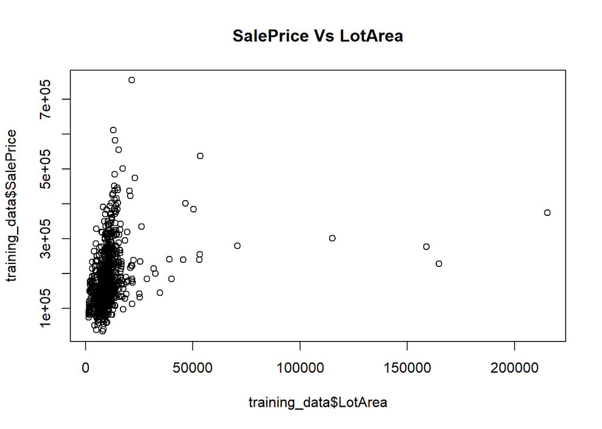

```r
plot(training_data$LotArea,training_data$SalePrice)
title("SalePrice Vs LotArea")
```

```r
xlab("LotArea")
```

```
## $x
## [1] "LotArea"
##
## attr(,"class")
## [1] "labels"
```

```r
ylab("SalePrice")
```

```
## $y
## [1] "SalePrice"
##
## attr(,"class")
## [1] "labels"
```

#Further, we have also plotted box plots for all the variables.

#First, we have created a vector with all the variables

```r
Variables_vars <- c("LotArea", "OverallQual","YearBuilt","YearRemodAdd","BsmtFinSF1","FullBath","HalfBath","BedroomAbvGr", "TotRmsAbvGrd","Fireplaces","GarageArea", "YrSold", "SalePrice")

Variables_vars
```

```
##  [1] "LotArea"      "OverallQual"  "YearBuilt"    "YearRemodAdd" "BsmtFinSF1"
##  [6] "FullBath"     "HalfBath"     "BedroomAbvGr" "TotRmsAbvGrd" "Fireplaces"
## [11] "GarageArea"   "YrSold"       "SalePrice"
```

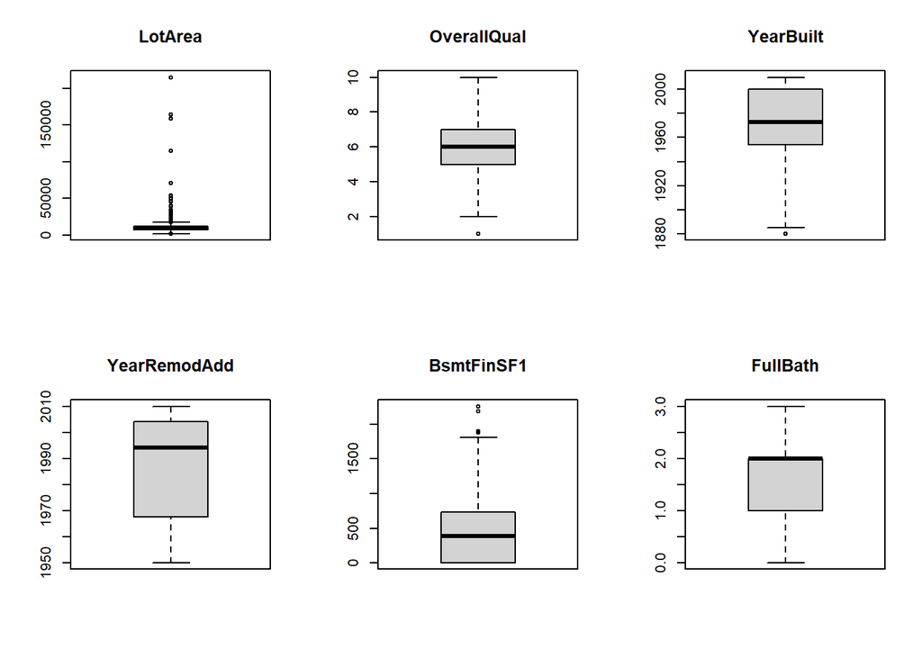

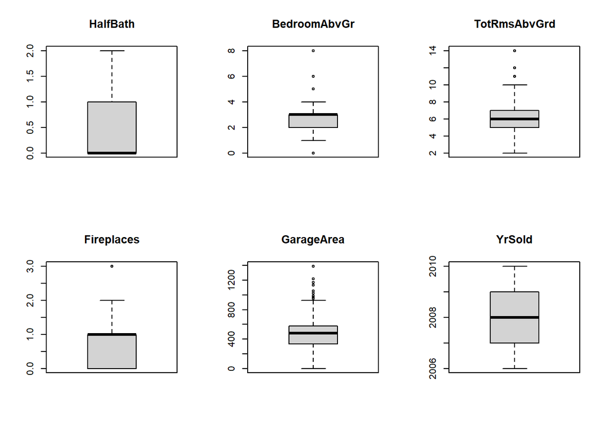

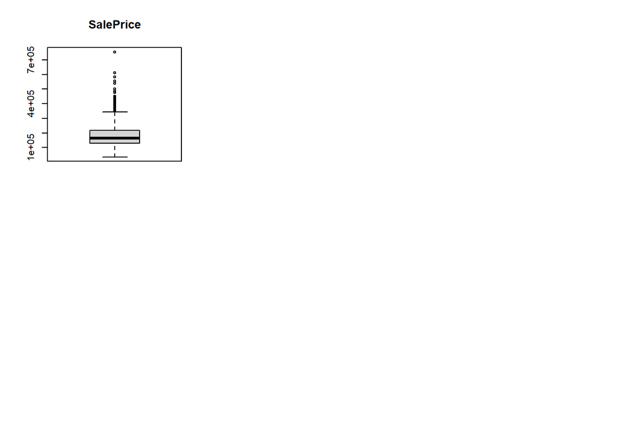

```r
par(mfrow = c(2, 3))
for (var in Variables_vars) {

# Plot the boxplot
boxplot(training_data[[var]], main = var)
}
```

We have done the exploratory analysis by performing box plots on all the variables.

1. Build a regression [module 5] and decision tree [module 7] model that can accurately predict the price of a house based on several predictors (you select appropriate features).

##Regression model

#read the “BA_Predict.csv” as the testing data

```r
testing_data <- read.csv("C:/Users/navat/Downloads/BA-Predict1.csv")
```

```r
head(testing_data)
```

```
##   LotArea OverallQual YearBuilt YearRemodAdd BsmtFinSF1 FullBath HalfBath
## 1    7340           4      1971         1971        322        1        0
## 2    8712           5      1957         2000        860        1        0
## 3    7875           7      2003         2003          0        2        1
## 4   14859           7      2006         2006          0        2        0
## 5    6173           5      1967         1967        599        1        0
## 6    9920           5      1954         1954        354        1        0
##   BedroomAbvGr TotRmsAbvGrd Fireplaces GarageArea YrSold SalePrice
## 1            2            4          0        684   2007    110000
## 2            2            5          0        756   2009    153000
## 3            3            8          1        393   2006    180000
## 4            3            7          1        690   2006    240000
## 5            3            6          0        288   2007    125500
## 6            3            6          0        280   2010    128000
```

```r
str(training_data)
```

```
## 'data.frame':    900 obs. of  13 variables:
##  $ LotArea     : int  8450 9600 11250 9550 14260 14115 10084 10382 6120 7420 ...
##  $ OverallQual : int  7 6 7 7 8 5 8 7 7 5 ...
##  $ YearBuilt   : int  2003 1976 2001 1915 2000 1993 2004 1973 1931 1939 ...
##  $ YearRemodAdd: int  2003 1976 2002 1970 2000 1995 2005 1973 1950 1950 ...
##  $ BsmtFinSF1  : int  706 978 486 216 655 732 1369 859 0 851 ...
##  $ FullBath    : int  2 2 2 1 2 1 2 2 2 1 ...
##  $ HalfBath    : int  1 0 1 0 1 1 0 1 0 0 ...
##  $ BedroomAbvGr: int  3 3 3 3 4 1 3 3 2 2 ...
##  $ TotRmsAbvGrd: int  8 6 6 7 9 5 7 7 8 5 ...
##  $ Fireplaces  : int  0 1 1 1 1 0 1 2 2 2 ...
##  $ GarageArea  : int  548 460 608 642 836 480 636 484 468 205 ...
##  $ YrSold      : int  2008 2007 2008 2006 2008 2009 2007 2009 2008 2008 ...
##  $ SalePrice   : int  208500 181500 223500 140000 250000 143000 307000 200000 129900 118000 ...
```

```r
str(testing_data)
```

```
## 'data.frame':    90 obs. of  13 variables:
##  $ LotArea     : int  7340 8712 7875 14859 6173 9920 13501 11500 8885 12589 ...
##  $ OverallQual : int  4 5 7 7 5 5 8 7 5 6 ...
##  $ YearBuilt   : int  1971 1957 2003 2006 1967 1954 2006 1936 1983 2005 ...
##  $ YearRemodAdd: int  1971 2000 2003 2006 1967 1954 2006 1987 1983 2005 ...
##  $ BsmtFinSF1  : int  322 860 0 0 599 354 63 223 301 0 ...
##  $ FullBath    : int  1 1 2 2 1 1 2 1 1 2 ...
##  $ HalfBath    : int  0 0 1 0 0 0 0 1 0 1 ...
##  $ BedroomAbvGr: int  2 2 3 3 3 3 3 3 2 3 ...
##  $ TotRmsAbvGrd: int  4 5 8 7 6 6 8 6 5 8 ...
##  $ Fireplaces  : int  0 0 1 1 0 0 1 1 0 1 ...
##  $ GarageArea  : int  684 756 393 690 288 280 865 180 484 390 ...
##  $ YrSold      : int  2007 2009 2006 2006 2007 2010 2007 2006 2006 2009 ...
##  $ SalePrice   : int  110000 153000 180000 240000 125500 128000 255000 250000 131000 174000 ...
```

```r
dim(training_data)
```

```
## [1] 900  13
```

```r
dim(testing_data)
```

```
## [1] 90 13
```

#performing the regression model

```r
regression_model <- lm(SalePrice ~ GarageArea + YearBuilt + FullBath + OverallQual + LotArea + BsmtFinSF1 + YearRemodAdd + Fireplaces , data = training_data)
```

#summarize the regression model

```r
summary(regression_model)
```

```
##
## Call:
## lm(formula = SalePrice ~ GarageArea + YearBuilt + FullBath +
##     OverallQual + LotArea + BsmtFinSF1 + YearRemodAdd + Fireplaces,
##     data = training_data)
##
## Residuals:
##     Min      1Q  Median      3Q     Max
## -256690  -22494   -3410   17127  346829
##
## Coefficients:
##                Estimate Std. Error t value Pr(>|t|)
## (Intercept)  -8.304e+05  1.661e+05  -4.999 6.94e-07 ***
## GarageArea    7.782e+01  8.276e+00   9.403  < 2e-16 ***
## YearBuilt    -7.434e+01  6.100e+01  -1.219    0.223
## FullBath      2.037e+04  2.997e+03   6.797 1.96e-11 ***
## OverallQual   2.738e+04  1.493e+03  18.342  < 2e-16 ***
## LotArea       7.154e-01  1.173e-01   6.101 1.57e-09 ***
## BsmtFinSF1    3.165e+01  3.282e+00   9.641  < 2e-16 ***
## YearRemodAdd  4.496e+02  8.453e+01   5.319 1.32e-07 ***
## Fireplaces    1.441e+04  2.308e+03   6.242 6.69e-10 ***
## ---
## Signif. codes:  0 '***' 0.001 '**' 0.01 '*' 0.05 '.' 0.1 ' ' 1
##
## Residual standard error: 39460 on 891 degrees of freedom
## Multiple R-squared:  0.7699, Adjusted R-squared:  0.7679
## F-statistic: 372.7 on 8 and 891 DF,  p-value: < 2.2e-16
```

#extract the residuals from the regression model

```r
residuals <- resid(regression_model)
```

#plotting a histogram of the residuals

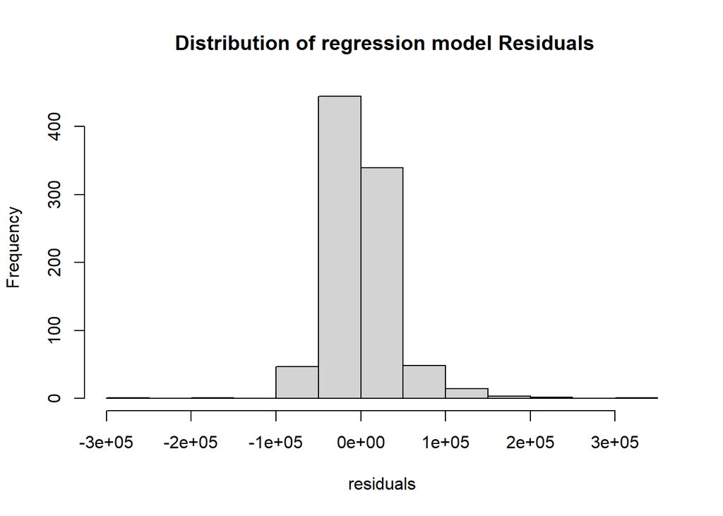

```r
hist(residuals,main =" Distribution of regression model Residuals",xlab= "residuals")
```

#Predicting the regression model

```r
regression_model_predictions <- predict(regression_model,newdata = testing_data)
```

#printing the regression model predictions

```r
print(regression_model_predictions)
```

```
##         1         2         3         4         5         6         7         8
## 107716.54 172787.86 204195.18 233429.60 110712.75 100139.39 275453.14 174688.99
##         9        10        11        12        13        14        15        16
## 124478.95 180701.63 142341.40 106532.29 115280.08 160246.34 180978.87  62359.64
##        17        18        19        20        21        22        23        24
## -11903.54 101293.56 239207.81 194491.56 191277.71 147045.52 180899.47 189723.88
##        25        26        27        28        29        30        31        32
## 206694.87 166512.25 255444.46 217216.17 243701.35 224991.50 236816.38 114769.25
##        33        34        35        36        37        38        39        40
## 293540.31 205008.28 245501.92  79555.78 230335.47 240059.24 243195.11 207633.65
##        41        42        43        44        45        46        47        48
## 199388.48 227520.82 112752.77 148005.74 157993.15 159916.82 167789.19 309852.23
##        49        50        51        52        53        54        55        56
## 214509.32 214258.83 155703.90 113389.15 137595.52 167406.83 152311.59 165307.10
##        57        58        59        60        61        62        63        64
## 157498.59 126381.25 223059.05 210689.24 111211.73 224203.76 183950.98 272997.02
##        65        66        67        68        69        70        71        72
## 235583.01 180151.69 128441.03 114490.20  10996.24 133140.24  38967.28 210473.21
##        73        74        75        76        77        78        79        80
## 157780.00 201201.72 185186.39 212758.81  40991.41 217115.63  88024.57 127689.54
##        81        82        83        84        85        86        87        88
## 219990.43 282296.07 201949.79 263655.68 138237.59 117921.38 136376.57 331960.35
##        89        90
## 186897.01 208290.95
```

##Decision Tree Model

```r
DT_model <- rpart(SalePrice ~ GarageArea + YearBuilt + FullBath + OverallQual + LotArea + BsmtFinSF1 + YearRemodAdd + Fireplaces , data = training_data)
```

#summarize the decision tree model

```r
summary(DT_model)
```

```
## Call:
## rpart(formula = SalePrice ~ GarageArea + YearBuilt + FullBath +
##     OverallQual + LotArea + BsmtFinSF1 + YearRemodAdd + Fireplaces,
##     data = training_data)
##   n= 900
##
##            CP nsplit rel error    xerror       xstd
## 1  0.47785266      0 1.0000000 1.0029823 0.09027878
## 2  0.11551089      1 0.5221473 0.5266435 0.04705688
## 3  0.05814644      2 0.4066365 0.4118299 0.04466716
## 4  0.02917450      3 0.3484900 0.3783707 0.03660016
## 5  0.01958114      4 0.3193155 0.3695052 0.03695725
## 6  0.01613203      5 0.2997344 0.3575427 0.03541524
## 7  0.01429023      6 0.2836024 0.3566584 0.03849255
## 8  0.01200980      7 0.2693121 0.3477185 0.03850610
## 9  0.01183168      8 0.2573023 0.3310571 0.03781150
## 10 0.01000000      9 0.2454707 0.3253894 0.03782785
##
## Variable importance
##  OverallQual   GarageArea    YearBuilt   BsmtFinSF1 YearRemodAdd     FullBath
##           54           14           11           10            5            4
##   Fireplaces      LotArea
##            1            1
##
## Node number 1: 900 observations,    complexity param=0.4778527
##   mean=183107.9, MSE=6.701496e+09
##   left son=2 (754 obs) right son=3 (146 obs)
##   Primary splits:
##       OverallQual  < 7.5     to the left,  improve=0.4778527, (0 missing)
##       YearBuilt    < 1984.5  to the left,  improve=0.3410164, (0 missing)
##       GarageArea   < 675.5   to the left,  improve=0.3352460, (0 missing)
##       FullBath     < 1.5     to the left,  improve=0.2765066, (0 missing)
##       YearRemodAdd < 1983.5  to the left,  improve=0.2410551, (0 missing)
##   Surrogate splits:
##       GarageArea   < 679     to the left,  agree=0.891, adj=0.329, (0 split)
##       YearBuilt    < 2005.5  to the left,  agree=0.863, adj=0.158, (0 split)
##       BsmtFinSF1   < 1336    to the left,  agree=0.860, adj=0.137, (0 split)
##       YearRemodAdd < 2007.5  to the left,  agree=0.850, adj=0.075, (0 split)
##       FullBath     < 2.5     to the left,  agree=0.843, adj=0.034, (0 split)
##
```

[output cut: 131 more lines]

```
##
## Node number 15: 10 observations
##   mean=474931.1, MSE=1.652827e+10
##
## Node number 16: 120 observations
##   mean=107412.9, MSE=6.818746e+08
##
## Node number 17: 252 observations
##   mean=137263.7, MSE=7.396912e+08
##
## Node number 18: 64 observations
##   mean=138261, MSE=1.15381e+09
##
## Node number 19: 122 observations
##   mean=179491.4, MSE=1.052756e+09
```

#plotting the decision tree model

[figure not shown]

```r
plot(DT_model)
text(DT_model)
```

#predicting the decision-tree model

```r
DT_model_predictions <- predict(DT_model,Newdata = testing_data)
```

#printing the decision-tree model predictions

```r
print(DT_model_predictions)
```

```
##        1        2        3        4        5        6        7        8
## 202038.8 179491.4 202038.8 202038.8 264630.2 137263.7 351838.2 202038.8
##        9       10       11       12       13       14       15       16
## 202038.8 137263.7 137263.7 474931.1 137263.7 202038.8 137263.7 202038.8
##       17       18       19       20       21       22       23       24
## 137263.7 138261.0 137263.7 137263.7 264630.2 202038.8 264630.2 137263.7
##       25       26       27       28       29       30       31       32
## 137263.7 264630.2 137263.7 264630.2 137263.7 107412.9 107412.9 107412.9
##       33       34       35       36       37       38       39       40
## 264630.2 137263.7 361925.2 264630.2 107412.9 137263.7 137263.7 138261.0
##       41       42       43       44       45       46       47       48
## 179491.4 137263.7 137263.7 137263.7 137263.7 361925.2 268469.5 264630.2
##       49       50       51       52       53       54       55       56
## 138261.0 137263.7 179491.4 107412.9 107412.9 361925.2 137263.7 179491.4
##       57       58       59       60       61       62       63       64
## 264630.2 202038.8 361925.2 137263.7 137263.7 107412.9 264630.2 202038.8
##       65       66       67       68       69       70       71       72
## 202038.8 264630.2 202038.8 268469.5 107412.9 202038.8 268469.5 137263.7
##       73       74       75       76       77       78       79       80
## 202038.8 137263.7 138261.0 137263.7 137263.7 137263.7 138261.0 107412.9
##       81       82       83       84       85       86       87       88
## 179491.4 179491.4 264630.2 107412.9 202038.8 264630.2 179491.4 179491.4
##       89       90       91       92       93       94       95       96
## 107412.9 137263.7 107412.9 137263.7 137263.7 179491.4 179491.4 179491.4
##       97       98       99      100      101      102      103      104
## 268469.5 137263.7 107412.9 137263.7 179491.4 179491.4 138261.0 202038.8
##      105      106      107      108      109      110      111      112
## 202038.8 264630.2 107412.9 107412.9 138261.0 179491.4 179491.4 202038.8
##      113      114      115      116      117      118      119      120
## 268469.5 179491.4 179491.4 179491.4 137263.7 107412.9 268469.5 179491.4
##      121      122      123      124      125      126      127      128
## 137263.7 107412.9 137263.7 179491.4 179491.4 137263.7 179491.4 107412.9
##      129      130      131      132      133      134      135      136
## 137263.7 137263.7 202038.8 179491.4 137263.7 264630.2 138261.0 202038.8
##      137      138      139      140      141      142      143      144
## 138261.0 202038.8 264630.2 179491.4 137263.7 268469.5 138261.0 202038.8
##      145      146      147      148      149      150      151      152
## 138261.0 179491.4 137263.7 202038.8 202038.8 107412.9 137263.7 351838.2
##      153      154      155      156      157      158      159      160
## 179491.4 137263.7 107412.9 107412.9 107412.9 264630.2 202038.8 202038.8
```

[output cut: 171 more lines]

```
## 179491.4 138261.0 137263.7 138261.0 107412.9 138261.0 202038.8 137263.7
##      849      850      851      852      853      854      855      856
## 179491.4 179491.4 137263.7 264630.2 202038.8 137263.7 137263.7 137263.7
##      857      858      859      860      861      862      863      864
## 137263.7 179491.4 202038.8 179491.4 202038.8 137263.7 179491.4 137263.7
##      865      866      867      868      869      870      871      872
## 202038.8 137263.7 264630.2 137263.7 138261.0 202038.8 107412.9 179491.4
##      873      874      875      876      877      878      879      880
## 107412.9 137263.7 107412.9 264630.2 137263.7 361925.2 137263.7 137263.7
##      881      882      883      884      885      886      887      888
## 137263.7 202038.8 179491.4 107412.9 137263.7 361925.2 138261.0 107412.9
##      889      890      891      892      893      894      895      896
## 264630.2 137263.7 107412.9 179491.4 137263.7 137263.7 138261.0 137263.7
##      897      898      899      900
## 137263.7 138261.0 474931.1 137263.7
```

##classification model

#converting the “OverallQual” feature from both the datasets of testing and training.

```r
training_data$OverallQual <- as.numeric(training_data$OverallQual)
testing_data$OverallQual <- as.numeric(testing_data$OverallQual)
```

```r
training_data$OverallQual <- as.factor(ifelse(training_data$OverallQual >= 7, 1, 0))
testing_data$OverallQual <- as.factor(ifelse(testing_data$OverallQual >= 7, 1, 0))

levels(training_data$OverallQual)
```

```
## [1] "0" "1"
```

```r
levels(testing_data$OverallQual)
```

```
## [1] "0" "1"
```

```r
classification_model <- glm(OverallQual ~ GarageArea + YearBuilt + FullBath + LotArea + BsmtFinSF1 + YearRemodAdd + Fireplaces, data = training_data, family = "binomial")
summary(classification_model)
```

```
##
## Call:
## glm(formula = OverallQual ~ GarageArea + YearBuilt + FullBath +
##     LotArea + BsmtFinSF1 + YearRemodAdd + Fireplaces, family = "binomial",
##     data = training_data)
##
## Coefficients:
##                Estimate Std. Error z value Pr(>|z|)
## (Intercept)  -1.516e+02  1.531e+01  -9.904  < 2e-16 ***
## GarageArea    5.697e-03  8.031e-04   7.093 1.32e-12 ***
## YearBuilt     1.813e-02  4.724e-03   3.839 0.000123 ***
## FullBath      1.193e+00  2.218e-01   5.377 7.56e-08 ***
## LotArea      -3.515e-06  7.384e-06  -0.476 0.634055
## BsmtFinSF1   -6.748e-04  2.500e-04  -2.699 0.006952 **
## YearRemodAdd  5.531e-02  7.953e-03   6.954 3.55e-12 ***
## Fireplaces    1.058e+00  1.719e-01   6.157 7.41e-10 ***
## ---
## Signif. codes:  0 '***' 0.001 '**' 0.01 '*' 0.05 '.' 0.1 ' ' 1
##
## (Dispersion parameter for binomial family taken to be 1)
##
##     Null deviance: 1195.32  on 899  degrees of freedom
## Residual deviance:  611.94  on 892  degrees of freedom
## AIC: 627.94
##
## Number of Fisher Scoring iterations: 6
```

```r
classification_model_predictions <- predict(classification_model, newdata = testing_data , type = "response")
```

```r
print(classification_model_predictions)
```

```
##            1            2            3            4            5            6
## 0.1154943936 0.3444629307 0.7546000353 0.9530658826 0.0084240096 0.0036246219
##            7            8            9           10           11           12
## 0.9814777645 0.0280297300 0.0923679116 0.7749585350 0.0516849575 0.0350886275
##           13           14           15           16           17           18
## 0.0041817535 0.2127016162 0.7490131827 0.0156670462 0.0011657040 0.0026047330
##           19           20           21           22           23           24
## 0.9368854054 0.4691844142 0.3311309828 0.0083569602 0.7893614538 0.7558149046
##           25           26           27           28           29           30
## 0.5625691178 0.1748054516 0.9347645512 0.2146677353 0.8451861704 0.8892437487
##           31           32           33           34           35           36
## 0.8292548230 0.0189642858 0.9728909659 0.7560249865 0.6998269857 0.0108419370
##           37           38           39           40           41           42
## 0.6029791045 0.9381914803 0.9355278914 0.0997724308 0.1772186520 0.5716039507
##           43           44           45           46           47           48
## 0.0063405255 0.1684405742 0.0617873986 0.0190234762 0.1807759544 0.9288102485
##           49           50           51           52           53           54
## 0.8160368085 0.6173781805 0.3663769394 0.0075337769 0.1075516657 0.2721374366
##           55           56           57           58           59           60
## 0.0075905934 0.0250845583 0.1772797790 0.0330413138 0.5932316098 0.4751710607
##           61           62           63           64           65           66
## 0.0124504832 0.7061657874 0.2793815364 0.8913584766 0.7922403680 0.7977833360
##           67           68           69           70           71           72
## 0.0153634720 0.0024291978 0.0003429415 0.0039792819 0.0006835614 0.5544706867
##           73           74           75           76           77           78
## 0.2019381706 0.7102041727 0.0699074124 0.4957446917 0.0006755477 0.3581536123
##           79           80           81           82           83           84
## 0.0062758352 0.0177644876 0.2391225199 0.8620010940 0.8029887504 0.9621974672
##           85           86           87           88           89           90
## 0.2648744515 0.0013527083 0.0268177297 0.8473362860 0.4801292104 0.8239450478
```

```r
predicted_classes <- ifelse(classification_model_predictions >= 0.5, 1, 0)

confusion_matrix <- table(predicted_classes, testing_data$OverallQual)
accuracy <- sum(diag(confusion_matrix)) / sum(confusion_matrix)

confusion_matrix
```

```
##
## predicted_classes  0  1
##                 0 47  8
##                 1  8 27
```

```r
cat("Accuracy:", accuracy, "\n")
```

```
## Accuracy: 0.8222222
```